# RT-Glo Cytation 2020-10-08 analysis

Darren Tyson

11/02/2020

```r
library(diprate)
```

Define loaction of files

```r
TOPDIR = '/mnt/darren/quaranta2/Cytation/2020-10-31'
SEGDIR = file.path(TOPDIR,'Segmentation')
```

### Assemble cell count data

Need to pull all cellcounts.csv files together. (Not needed. Assembled cell counts in Python)

#### Filename structure

Example filename: `B10_04_1_1_RFP_001.tif`

- `B10` = well
- `04` = unknown
- `1` = channel number (`1` or `2` in these data)
- `1` = position number (`1` or `2` in these data)
- `RFP` = channel name (`RFP` or `GFP` in these data)
- `001` = time point index (only `001` in these data; actual time point index in enclosing directory (2 up) `Experiment[0-9]{1,2}`)
- `tif` = image file format (only `tif` in these data)

```r
d <- cc
```

```r
d$pos <- sapply(strsplit(d$file_name, "_"), "[[", 4)
d$uid <- paste(d$plate_id,d$well,sep='_')
ccw <- sapply(unique(d$uid), function(id) sum(d[d$uid==id,'cell_count']))
ch2w <- sapply(unique(d$uid), function(id) sum(d[d$uid==id,'ch2_pos']))
# d <- d[d$pos==1,]
```

```r
d$cell.count <- ccw
d$ch2.pos <- ch2w
d <- d[,c('plate_id','well','uid','cell.count','ch2.pos')]
```

Add other relevant columns and platemap info.

```r
d$expt.date <- "2020-10-08"
d <- addMapInfo(d,"../data/201008_185701_Experiment1_platemap.tsv")
```

Must get image acquisition times from directory names

First, make function to extract date and time from directory name.

```r
getDateTime <- function(dname)
{
    o <- dname[sapply(dname, function(d) grepl("[0-9]{6}_[0-9]{6}",d))]
    mytime <- paste(sapply(strsplit(o,'_'), '[[', 1),
                    sapply(strsplit(o,'_'), '[[', 2), sep='_')
    mytime <- strptime(mytime, '%y%m%d_%H%M%S')
    names(mytime) <- NULL
    return(mytime)
}
```

Assemble directory names for each Experiment number

```r
im_time <- basename(list.dirs(dirname(SEGDIR), recursive=FALSE))
im_time <- im_time[!grepl('Segment',im_time)]
names(im_time) <- gsub('Experiment','',sapply(strsplit(im_time, '_'), '[[', 3))
im_time <- getDateTime(im_time)
```

Add image time to data

```r
d$image.time <- im_time[d$plate_id]
tx.time <- min(im_time) - (3600*6)
d$time <- signif(as.numeric(difftime(d$image.time,tx.time, units='hours')),4)
d <- d[order(d$well,d$time),]
rownames(d) <- NULL
```

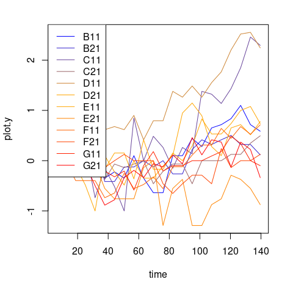

```r
cont <- d[d$drug1.conc==0,]
#do.call(plotGC, getGCargs(cont[cont$well %in% c('B11','C11','D11'),],
#                          dat.col = c("time", "cell.count", "well")))
invisible(do.call(plotGC, getGCargs(cont,
                          dat.col = c("time", "cell.count", "well"))))
```

# Summe cell counts across wells in same condition

To facilitate visualization due to the low cell numbers visible within each field of view.

```r
d$ucond <- paste(d$drug1,d$drug1.conc,d$time,sep='_')
a <- d[order(d$ucond),]
a_counts <- sapply(unique(a$ucond), function(x) sum(a[a$ucond==x,'cell.count']))
a_counts_ch2 <- sapply(unique(a$ucond), function(x) sum(a[a$ucond==x,'ch2.pos']))
a <- a[!duplicated(a$ucond),]
a$cell.count <- a_counts
a$ch2.pos <- a_counts_ch2
a <- a[order(a$well,a$time),]
```

### Examine control wells

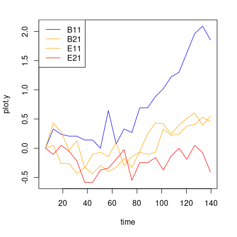

```r
cont <- a[a$drug1.conc==0,]
cont <- cont[order(cont$well,cont$time),]

invisible(do.call(plotGC, getGCargs(cont,
                          dat.col = c("time", "cell.count", "well"))))
```

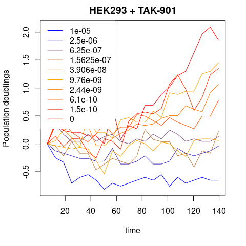

```r
invisible(do.call(plotGC, append(getGCargs(a[a$drug1=='TAK-901',],
                          dat.col = c("time", "cell.count", "drug1.conc")),
                          list(main='HEK293 + TAK-901', ylab='Population doublings'))))
```

#### Luminescence reads

Read in data, reformat and replace time with image time for direct comparisons

```r
lum <- read.csv("../data/HEK293lum.csv", as.is=TRUE)
lum_time <- lum[,1]
lum2 <- as.matrix(lum[,-1])
wells <- fixWellName(colnames(lum)[-1])
lum <- data.frame(time=rep(unique(d$time)),
                       lum=as.vector(lum2),
                       well=rep(wells, each=length(unique(d$time))))
lum$uid <- paste(match(lum$time, unique(lum$time)), lum$well, sep="_")
lum <- addMapInfo(lum,"../data/201008_185701_Experiment1_platemap.tsv")
```

```r
lum$ucond <- paste(lum$drug1,lum$drug1.conc,lum$time,sep='_')
a2 <- lum[order(lum$ucond),]
a2_lum <- sapply(unique(a2$ucond), function(x) sum(a2[a2$ucond==x,'lum']))
a2 <- a2[!duplicated(a2$ucond),]
a2$lum <- a2_lum
a2 <- a2[order(a2$well,a2$time),]
```

#### Combine all data

All data should be aligned by row such that can simply add luminescence reads to cell count data.

```r
if(all(a$uid==a2$uid))
{
    a$lum <- a2$lum
} else {
    message('Cell count data and luminescence data not aligned!')
}
```

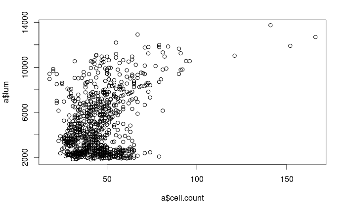

```r
plot(a$cell.count, a$lum)
```

#### Only control wells exhibiting clear exponential growth

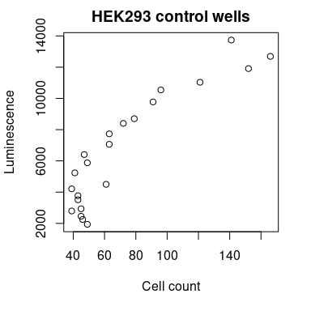

```r
a2 <- a[a$well=="B11",]
plot(lum ~ cell.count, data=a2,
     xlab="Cell count", ylab="Luminescence", main="HEK293 control wells")
```

Correlation of luminescence to cell counts in control wells

```r
round(cor(a2$cell.count,a2$lum),4)
```

```
[1] 0.9062
```

### Save combined data file

Only save if file does not already exist.

```r
dfn <- "../data/2020-10-08_Cytation_data_sum_by_condition.csv"
if(!file.exists(dfn)) write.csv(a, file=dfn, row.names=FALSE)
```

Also save data with all wells included

```r
d$lum <- lum$lum
cfn <- "../data/2020-10-08_Cytation_data_counts+lum.csv"
if(!file.exists(cfn)) write.csv(d, file=dfn, row.names=FALSE)
```